# Perihelion advance of Mercury

## Summary

The perihelion advance of Mercury is a well-known test of general relativity. Einstein calculated that Mercury’s perihelion would advance by 43 seconds of arc per century due to general relativistic effects; here I reproduce that analysis using numerical reasoning.

## Introduction

The orbit of Mercury has long been known to advance at a rate of about 575’’ [seconds of arc] per century. Various classical phenomena, such as the effects of Venus, and the oblateness of the sun, account for all but 43’’ and this remaining amount puzzled astronomers for many years. According to Einstein and others, the general theory of relativity predicts an additional precession of almost exactly 43 seconds per century, thus closing the gap between expectation and observation. In this document I will calculate the precessional rate using numerical methods.

## Closed and non-closed orbits.

Consider the following R idiom, in which `trajectory()` is used to directly simulate a geodesic in Schwarzschild space:

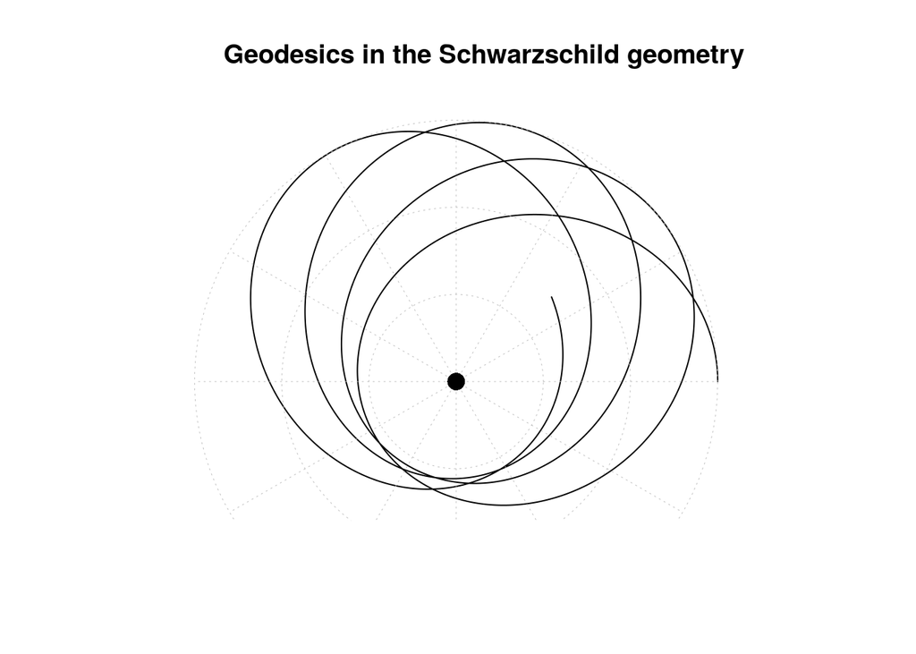

```r
# Simulate a trajectory starting at r=30, mass of sun=1/2 so Schwarzschild radius=1:
jj <- trajectory(r_start=30, m=1/2, h=3) # h=3 gives angular momentum
plot(jj$x,jj$y, asp=1, type='l', axes=FALSE, xlab='', ylab='',main='Geodesics in the Schwarzschild geometry')
polargrid(r=10*(1:3))
event_horizon()  # show the event horizon, to scale
```

(NB `trajectory()` takes geometrized units). In the above, we see a typical trajectory in Schwarzschild space with a precession of around 40 degrees per orbit. As a consistency check we can perform the same calculation but with Newtonian approximations:

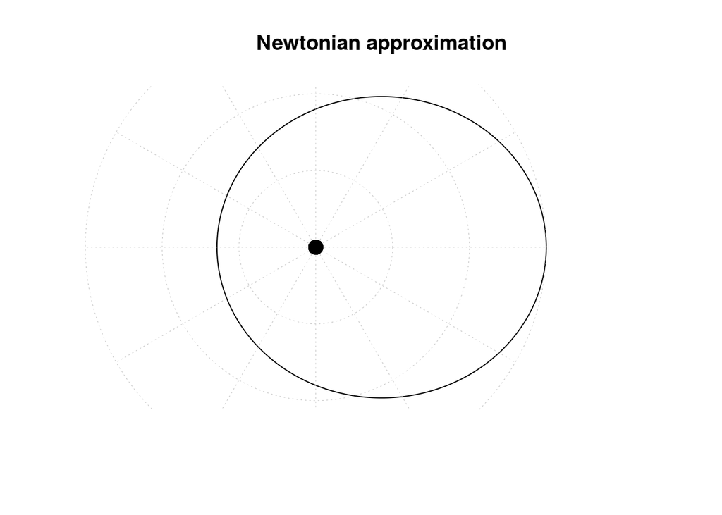

```r
jj <- trajectory(30, 1/2, 3, GR=FALSE) # GR=FALSE means use Newtonian approximation
plot(jj$x,jj$y, asp=1, type='l', axes=FALSE, xlab='', ylab='',main='Newtonian approximation')
polargrid(r=10*(1:3))
event_horizon()
```

and above we see that the orbit is accurately closed, as expected (three orbits are simulated, the lines overlap).

## Mercury

First we specify some orbital parameters for the orbit of Mercury, mostly taken from Wikipedia:

```r
G <-  6.674e-11     # big G in SI
M  <- 1.9885e30     # mass of Sun (kg)
M_merc <- 3.3011e23 # mass of Mercury (kg)
sol <- 299792458    # speed of light (m/s)
merc_perihelion <- 46001200e3
merc_aphelion   <- 69816900e3
mu <- G*(M + M_merc)
```

Now we calculate some features of the orbit in geometrized units:

```r
d <- G*M/sol^2  # mass of sun in meters
r_s <- 2*d      # Schwarzschild radius of Sun (=2M)
```

And some further features using classical geometry:

```r
a <- (merc_perihelion + merc_aphelion)/2
cee <- a-merc_perihelion
b <- sqrt(a^2-cee^2)
ecc <- sqrt(1-(b/a)^2)  # should match eccentricity given by Wikipedia
ell <- (a^2-cee^2)/a  # semi-latus rectum
```

Now calculate maximum and minimum orbital speeds:

```r
vmin <- sqrt(mu/ell)*(1-ecc)
vmax <- sqrt(mu/ell)*(1+ecc)
```

And we need to specify the orbital angular mometum in different units:

```r
specific_angular_momentum_SI <- merc_perihelion * vmax
h <- specific_angular_momentum_SI/sol #geometrized units
```

With all these we can simulate the orbit:

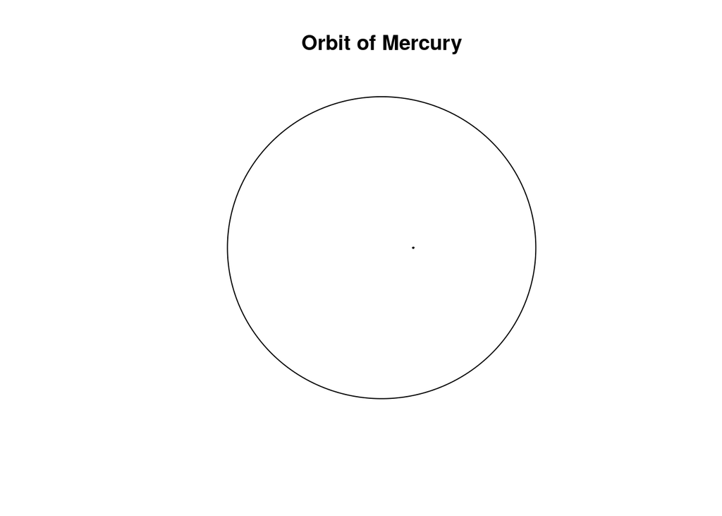

```r
 out <- trajectory(merc_perihelion, m=d, h=h, tau=seq(from=0,to=35e15,len=5e5))
 plot(out$x,out$y,type='l',asp=1,axes=FALSE,xlab='',ylab='',main='Orbit of Mercury')
 event_horizon()
```

```r
 max(out$phi/(2*pi))
```

```
## [1] 15.40312
```

In the above diagram we see over 15.4 orbits of Mercury, exhibiting no visible deviation from an exactly closed orbital path. Nevertheless, the orbit is not closed as Mercury has a tiny amount of orbital precession. To calculate this precession we need to simulate the motion for a longer time:

```r
out <- trajectory(merc_perihelion, m=d, h=h, tau=seq(from=0,to=35e16,len=1e7))
```

We need to isolate the change points (actually calculating aphelion rather than perihelion for convenience):

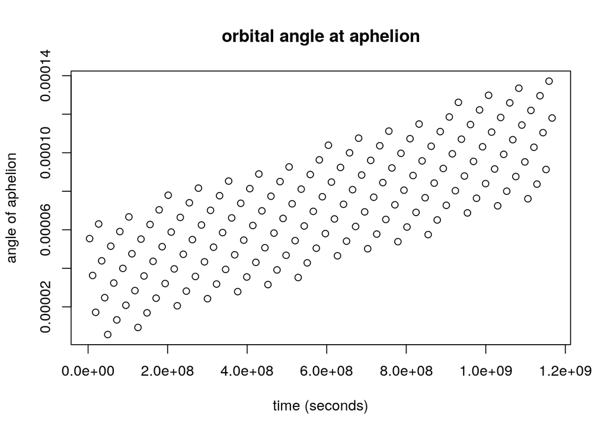

```r
jj1 <- c(NA,out$rdot)
jj2 <- c(out$rdot,NA)
change <- (jj1>0) & (jj2<0)

tee    <- out$time[change]

phi <- out$phi[change]
phi <- (phi) %% (2*pi)

plot(tee,phi-pi,main='orbital angle at aphelion',xlab='time (seconds)',ylab='angle of aphelion')
```

The above diagram shows a clear trend, somewhat obscured by a vertical spread due to the discrete nature of the simulation. To estimate the underlying trend, which is the general relativistic precession of Mercury, we can use linear regression:

```r
prec <- lm(phi~tee)$coefficients[2]
prec
```

```
##          tee
## 6.662703e-14
```

And to convert to astronomical units we use

```r
conversion <-
  c(
      seconds_per_minute = 60,
      minutes_per_hour   = 60,
      hours_per_day      = 24,
      days_per_year      = 365.25,
      years_per_century  = 100,
      degrees_per_radian = 180/pi,
      minutes_per_degree = 60,
      seconds_per_minute = 60
  )
```

giving

```r
prec*prod(conversion)
```

```
##      tee
## 43.36902
```

closely agreeing with Einstein’s original prediction of 43’’. A more careful analysis would account for the nonzero mass of Mercury.

## Theoretical analysis

In current notation, a first-order analysis gives

$$\frac{24\pi^3a^2}{t^2c^2\left(1-e^2\right)}$$

for the precession. In R idiom:

```r
precession <- 24*pi^3*a^2/(per^2*sol^2*(1-ecc^2))  # radians/orbit
precession
```

```
## [1] 5.018671e-07
```

To convert this figure (which is given in radians per orbit) to the more usual units of arcseconds per century, we need to multiply by a sequence of factors:

```r
seconds_per_orbit <- prod(c(
    seconds_per_minute = 60,
    minutes_per_hour   = 60,
    hours_per_day      = 24,
    days_per_orbit     = 87.969
))

seconds_per_century <- prod(c(
    seconds_per_minute = 60,
    minutes_per_hour   = 60,
    hours_per_day      = 24,
    days_per_year      = 365.25,
    years_per_century  = 100
))

orbits_per_century <- seconds_per_century/seconds_per_orbit

arcseconds_per_radian <- prod(
    c(
        degrees_per_radian = 180/pi,
        minutes_per_degree = 60,
        seconds_per_minute = 60
         ))

arcseconds_per_orbit <- precession*arcseconds_per_radian
arcseconds_per_century <- arcseconds_per_orbit * orbits_per_century
arcseconds_per_century
```

```
## [1] 42.98079
```

Compare with the value of about 43.37 obtained from numerical integration, showing close agreement.